## Reproducible Research: Peer Assessment 1

This assignment is broken into 5 parts, each part will deal with different aspects of reproducible research.

### Loading and preprocessing the data

To load in the csv file I used the `read.csv()` function. I then used the `transform()` function to convert the date field from a factor to a date type.

```r
activity <- read.csv(file="activity.csv")
activity <- transform(activity, date = as.Date(date))
```

### What is mean total number of steps taken per day?

Once the data is in the correct format I can now create some exploratory graphs using the `ggplot()` function in the `ggplot2` package. This needs to be loaded into R using the `library()` function.

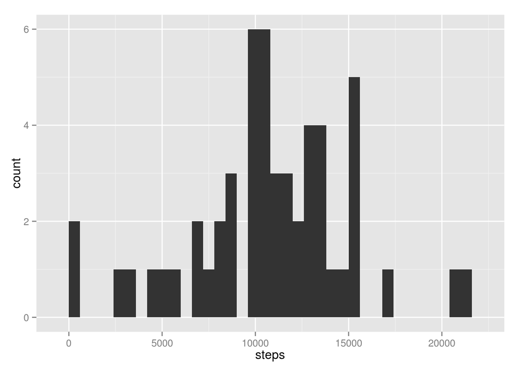

```r
library(ggplot2)
aggData <- aggregate(steps ~ date, data=activity, FUN=sum)
ggplot(aggData, aes(steps)) + geom_histogram(binwidth=600)
```

The mean and median can be calculated using the `aggData` variable we created and the `mean()` and `median()` functions as follows;

```r
meanSteps <- mean(aggData$steps)
meanSteps
```

```
## [1] 10766
```

```r
medianSteps <- median(aggData$steps)
medianSteps
```

```
## [1] 10765
```

### What is the average daily activity pattern?

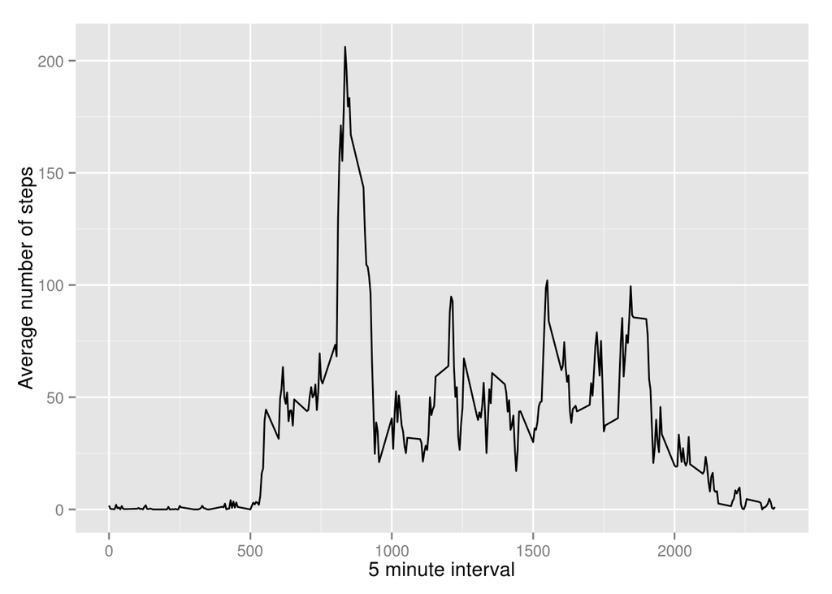

```r
aggDataInterval <- aggregate(steps ~ interval, data=activity, FUN=mean)
ggplot(aggDataInterval, aes(interval,steps)) + geom_line() +
        xlab("5 minute interval") + ylab("Average number of steps")
```

The 5-minute interval with the highest average number of steps can be found using the `which.max()` function and indexing into the aggregate data frame;

```r
aggDataInterval[which.max(aggDataInterval$steps), ]
```

```
##     interval steps
## 104      835 206.2
```

### Imputing missing values

Here is the total number of `NA` values in the dataset.

```r
sapply(activity, function(x)sum(is.na(x)))
```

```
##    steps     date interval
##     2304        0        0
```

Begin by copying the `activity` data frame into a new varible called `activity2`. We can fill the missing values by using the 5 minute interval mean. We create a new column in the `activity2` data frame that will hold the interval means and then replace the `NA` values in the `steps` column with these means. We can see using the `sapply` function that the `NA` are gone.

```r
activity2 <- activity
activity2$meanInterval <- ave(activity$steps, activity$interval, FUN=function(x) mean(x, na.rm=T))
activity2$steps[is.na(activity2$steps)] <- activity2$meanInterval
sapply(activity2, function(x)sum(is.na(x)))
```

```
##        steps         date     interval meanInterval
##            0            0            0            0
```

New histogram using the filled in values.

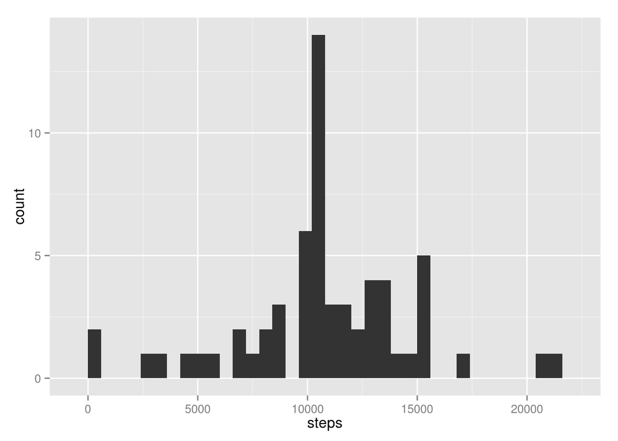

```r
aggData2 <- aggregate(steps ~ date, data=activity2, FUN=sum)
ggplot(aggData2, aes(steps)) + geom_histogram(binwidth=600)
```

The mean and median can be calculated using the `aggData2` variable we created and the `mean()` and `median()` functions as follows;

```r
meanSteps2 <- mean(aggData2$steps)
meanSteps2
```

```
## [1] 10766
```

```r
medianSteps2 <- median(aggData2$steps)
medianSteps2
```

```
## [1] 10766
```

### Are there differences in activity patterns between weekdays and weekends?

Here we will continue using the `activity2` data with the filled in `NA` values.

```r
weekend = c("Saturday", "Sunday")
weekFact <- factor(c("weekend", "weekday"))
activity2$week <- weekFact[(as.numeric(weekdays(activity2$date) %in% weekend)+1)]
```

We’ll use the `lattice` package to make a panel plot for the number of steps on the weekend days versus weekdays.

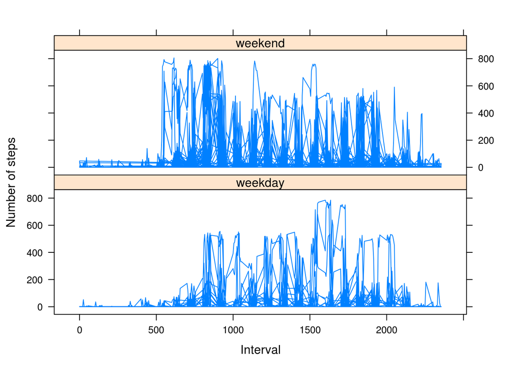

```r
library(lattice)
xyplot(activity2$steps ~ activity2$interval | activity2$week, layout=c(1,2),
        type="l",xlab="Interval",ylab="Number of steps")
```